# Bivariate Plots Section

## Total Exemptions vs. Enrollment

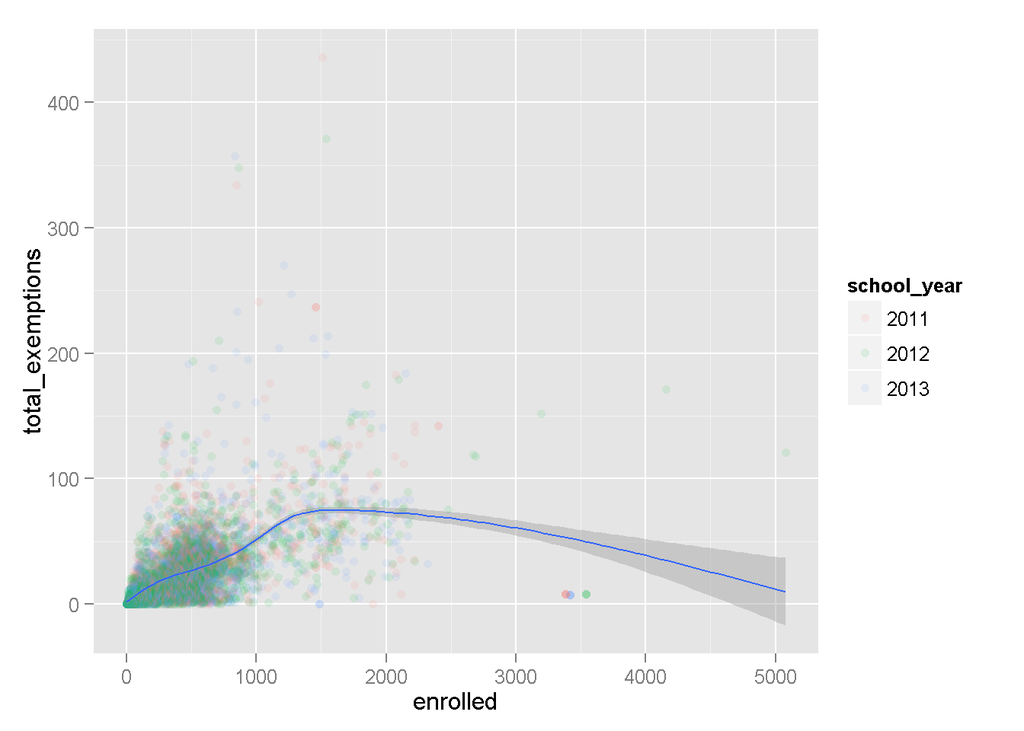

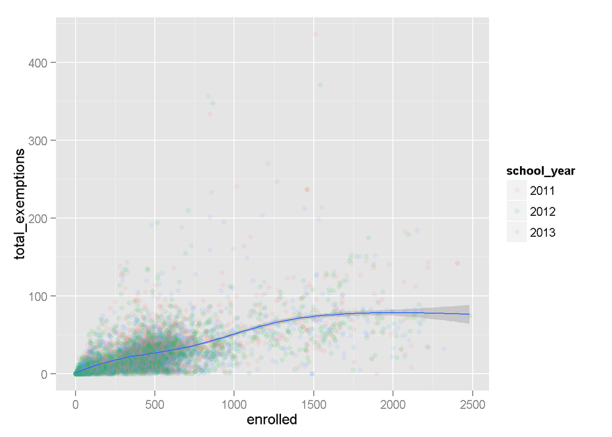

For most of the data (enrollment up to ~1500) there is a linear relationship between total exemptions and number of students enrolled, this isn’t surprising.  
It would be more intersting to look at the rate, since it is normalized for population.

## Exemption rate vs enrollment

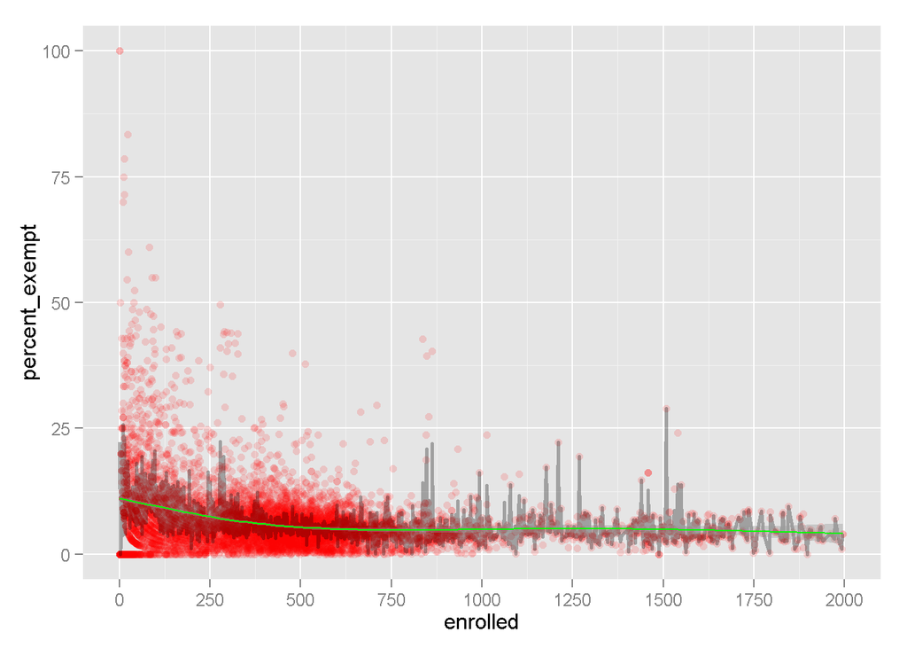

Black: Grand mean Green: Smooth

Mean percent exempt has high variance at low levels of enrollment.  
This make sense, since a small change in exemptions represents a larger proportion of the population vs. schools with higher levels of enrollment.

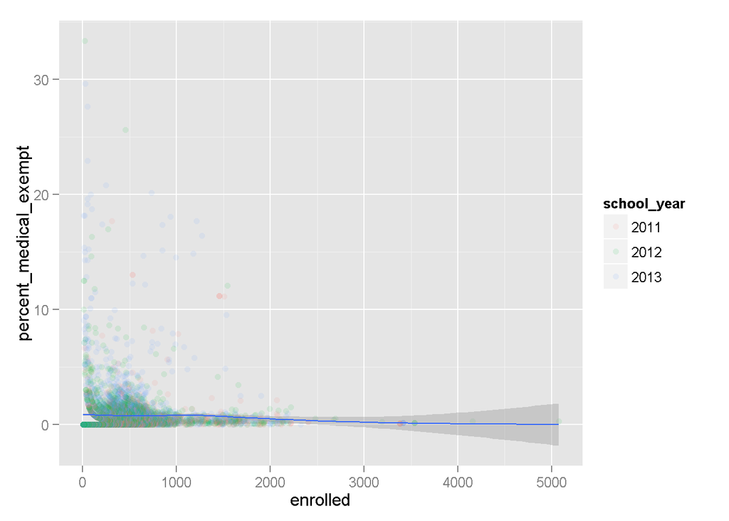

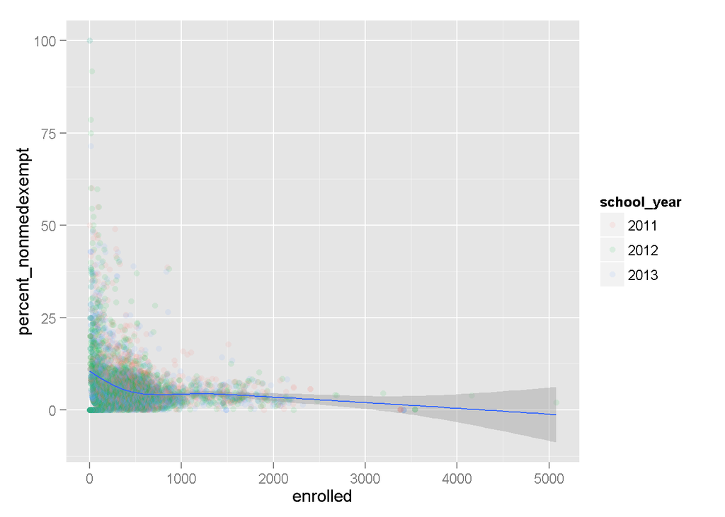

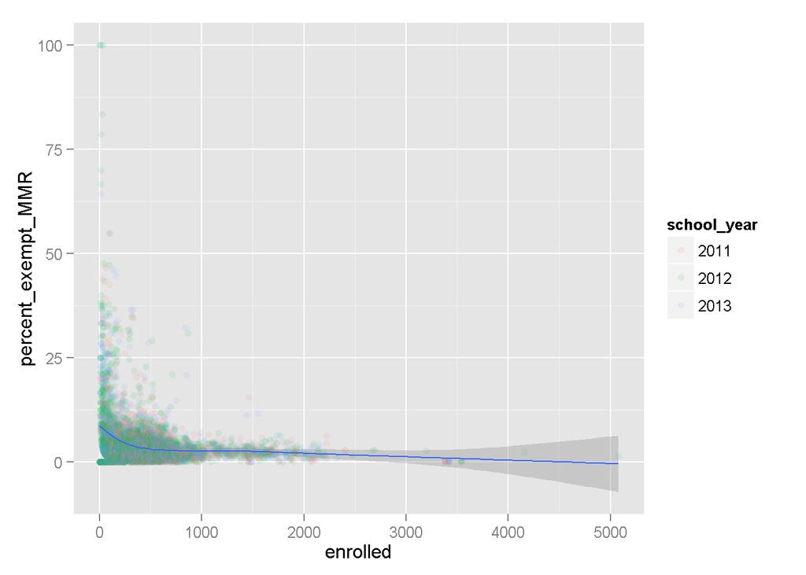

Percent exemption drops sharply from low to higher levels of enrollment.

## Specific exemptions vs. enrollment

The intent of these plots it to inform how specific exemptions vary with enrollment levels.

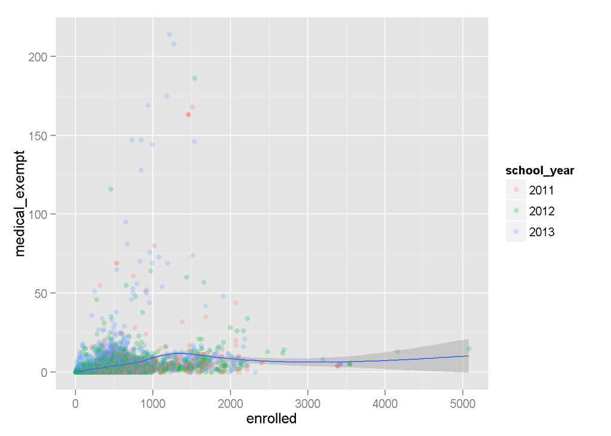

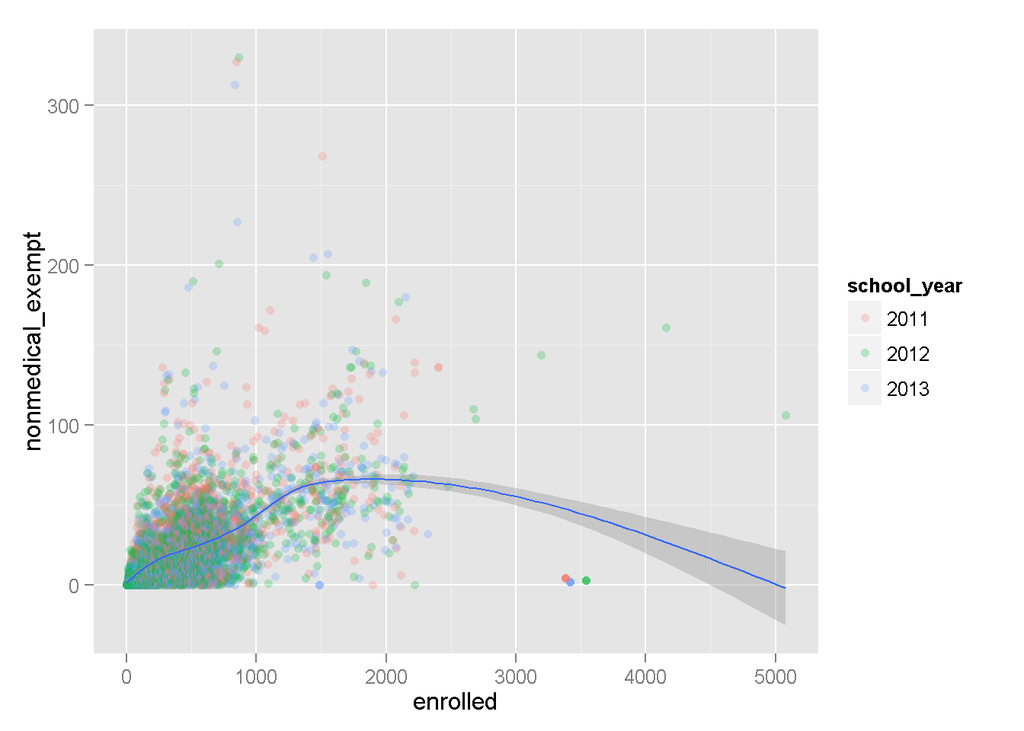

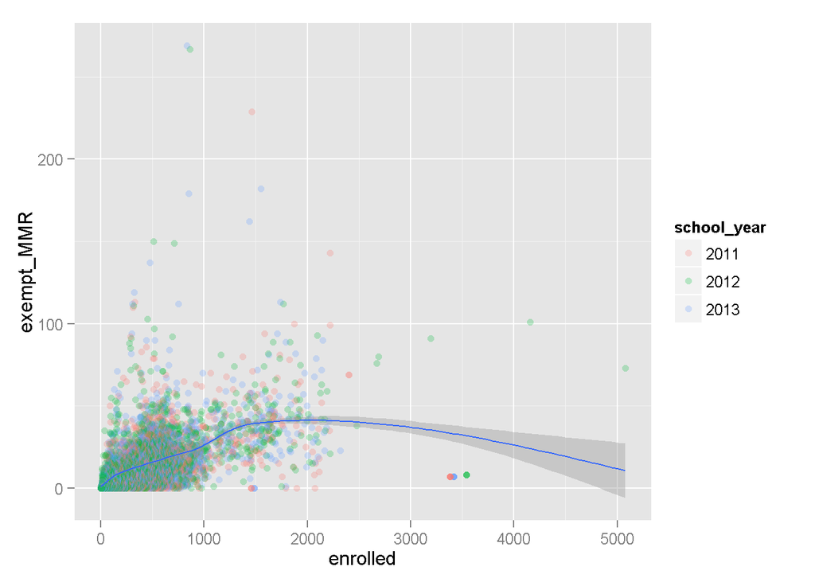

```
##
##  Pearson's product-moment correlation
##
## data:  vaccReported$enrolled and vaccReported$nonmedical_exempt
## t = 52.0693, df = 6694, p-value < 2.2e-16
## alternative hypothesis: true correlation is not equal to 0
## 95 percent confidence interval:
##  0.5196347 0.5537363
## sample estimates:
##       cor
## 0.5369048
```

[output not shown]

Strong correlation between number of students enrolled and both non-medical exempt and MMR exemption. It is interesting to note that there are some schools that appear to have numbers of medical exempt well above what would be expected by the overall trend. Getting a sense for these relationships underscores how much more useful exemption rates are over total exemptions.

## Specific exemptions vs. total exemptions

The intent of this section is to get a sense how specific exemptions vary as a funcion of total exemptions. This is an attempt to get a sense for proportional contribution of exemption types overall exemptions.

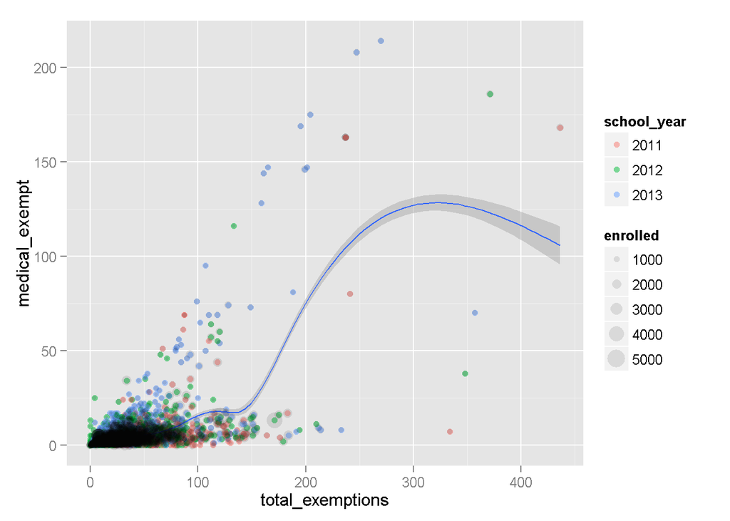

There is an interesting relationship between total exemptions and medical exemptions. The correlation is weak up to about 150 exemptions and then takes off, becoming negative at about 300 exemptions. Some of this is because there a very few schools beyond 150 exemptions, but note by the point size that this does not track strictly to school size (number of enrolled students).

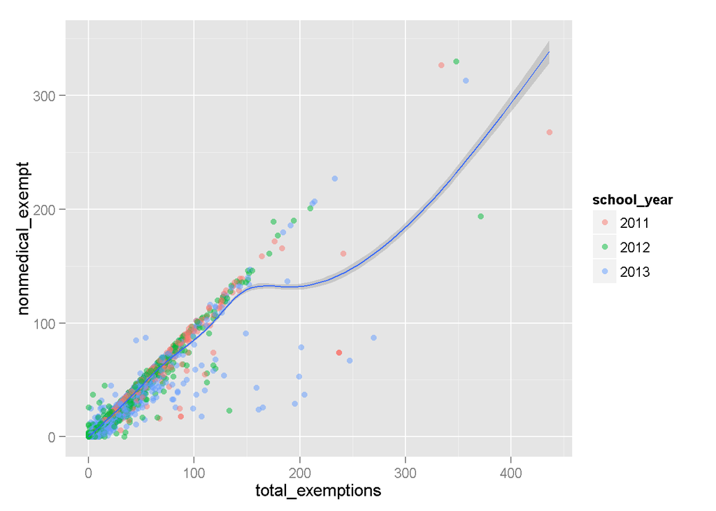

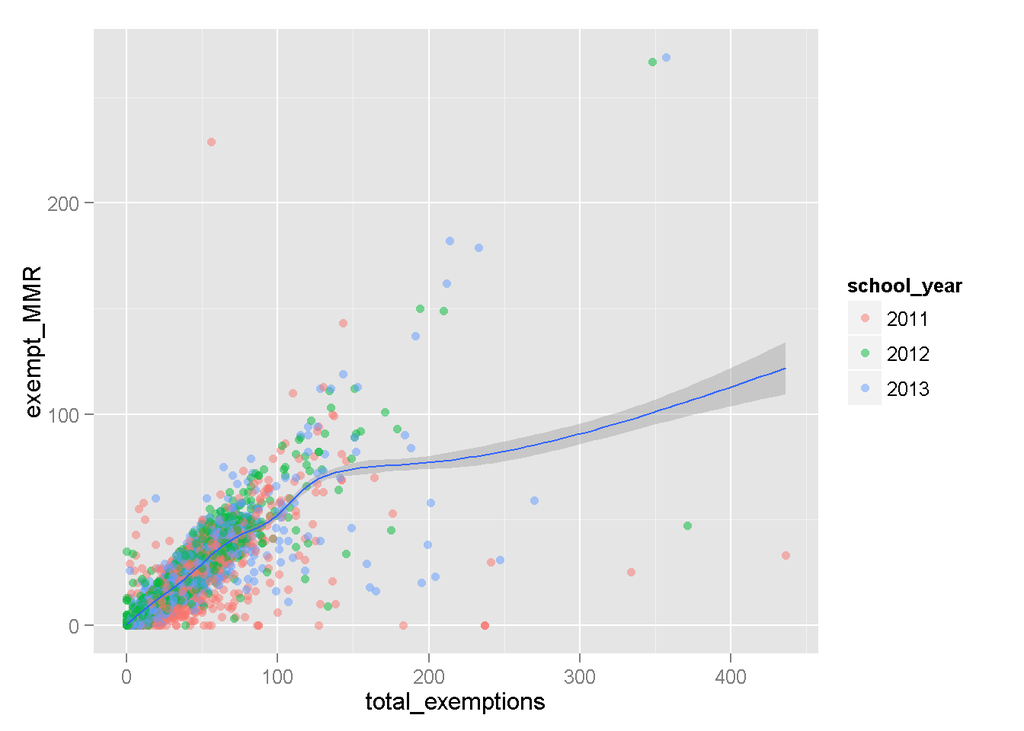

There is a strong positive correlation between total exemptions and non-medical exemptions. The is also a strong positive correlation between total exemptions and MMR exemptions, but not as strong as non-medical exemptions.

## Specific exemption rates vs. total exemption rate

This section provides a sense of the strength of the relationships between specific and total exemption rates.

Default smooth:

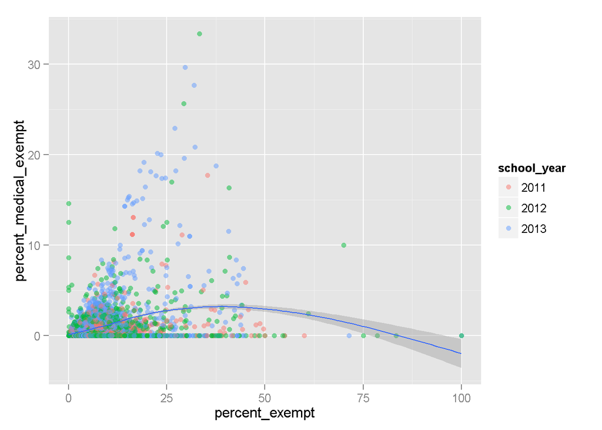

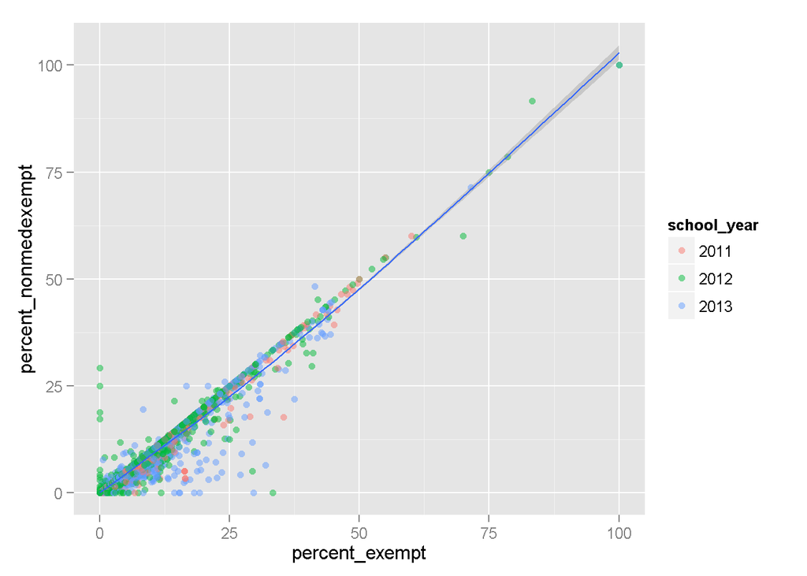

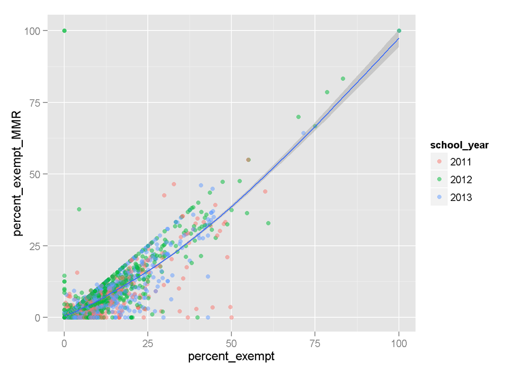

Smooth with method = lm (attempt linear fit)

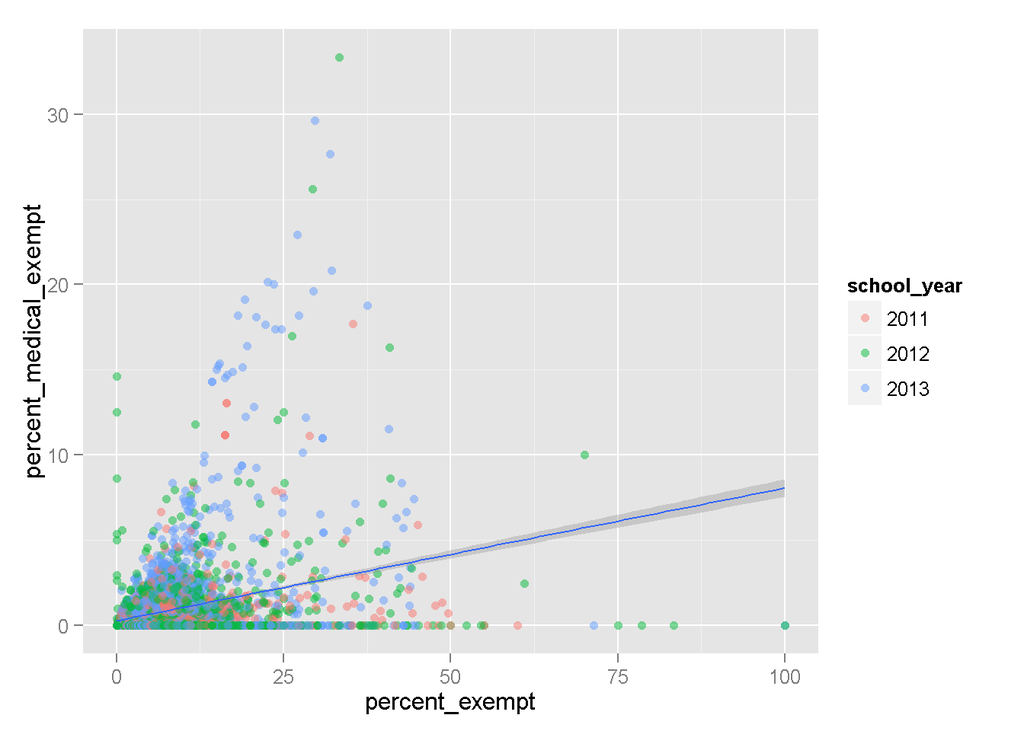

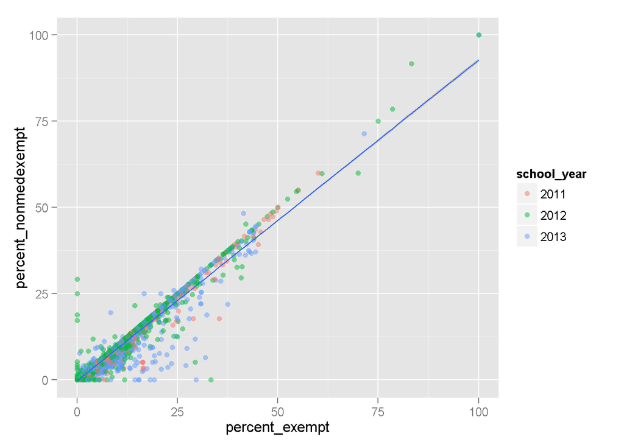

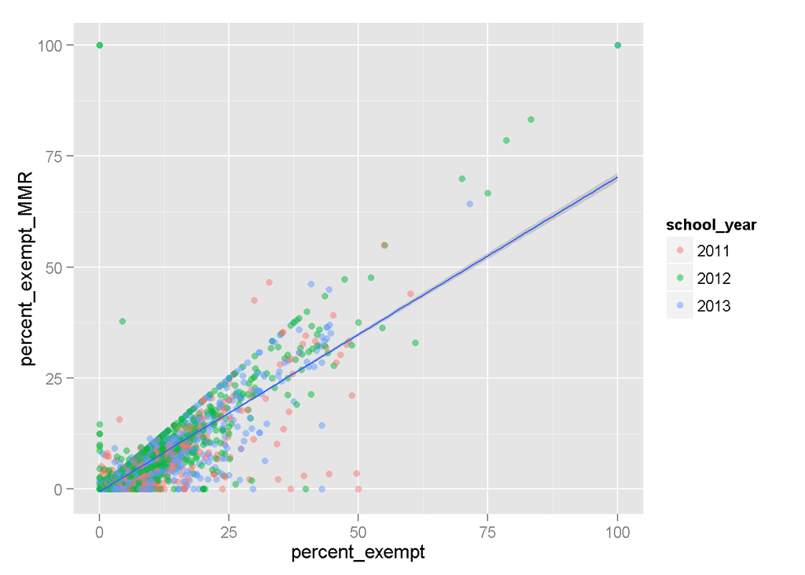

Both sets of plots are informative and it is interesting to see how the smooth method choice affects the attempted fit. The overall information gleaned here is not suprising at this point, which is that MMR and non-medical exemption rates have a stronger linear correlation with the overall exemption rate vs. the medical exemption rate.

What are those rates for a linear fit?

Non-medical:

```
##
## Call:
## lm(formula = percent_nonmedexempt ~ percent_exempt, data = vaccReported)
##
## Coefficients:
##    (Intercept)  percent_exempt
##        -0.2264          0.9300
```

MMR Rate

```
##
## Call:
## lm(formula = percent_exempt_MMR ~ percent_exempt, data = vaccReported)
##
## Coefficients:
##    (Intercept)  percent_exempt
##        -0.5163          0.7083
```

I have strong interest in MMR exemptions, since the first M (measles) in MMR is highly contageous and easily spread. The functions and code below, which I am showing for the the sake of clarity, calulate the predicted MMR rate and non-medical exemption rate using a linear fit.

```r
# function to solve for y in y = mx + b, for a given x
lm_y <- function(lin, x) {
  m = coef(lin)[2]
  b = coef(lin)[1]
  return((m*x) + b)

}


lm_y(linear_MMR_rate,10)
```

```
## percent_exempt
##       6.566816
```

```r
lm_y(linear_nonmed_rate,10)
```

```
## percent_exempt
##       9.074078
```

```r
# function to solve for x in y = mx + b, for a given x
lm_x <- function(lin, y) {
  m = coef(lin)[2]
  b = coef(lin)[1]
  return((y-b)/m)

}

#solve lm predicted total exemption rate for a 5% MMR exemption rate
lm_x(linear_MMR_rate,5)
```

```
## (Intercept)
##    7.787952
```

According to the power of basic math, it appears that if a school has an ~ 8% vaccine exemption rate, you can count on MMR exemptions being ~5%. Some physcians and scientists consider this a a line in the sand that should not be crossed in terms of risk to the immune suppressed and non-immune population (note that some people who are vaccinated are resistant but not immune). I had intended to use this later on in the analysis to a greater extent but decided not to because there is still too much variability to make a blanket statement like “if a school is at or above x% total exemptions then it is likely above x% threshold for MMR.” It was tempting and would be useful if I didn’t have the actual MMR data, but I do. There may be some model building opportunities here to make predictions elsewhere, where MMR or other vaccination records are less complete but where total exemtpions are known.

## Box Plots

Would you could you with a fox, would you could you with box plots? You are welcome.

## Exemptions by school type

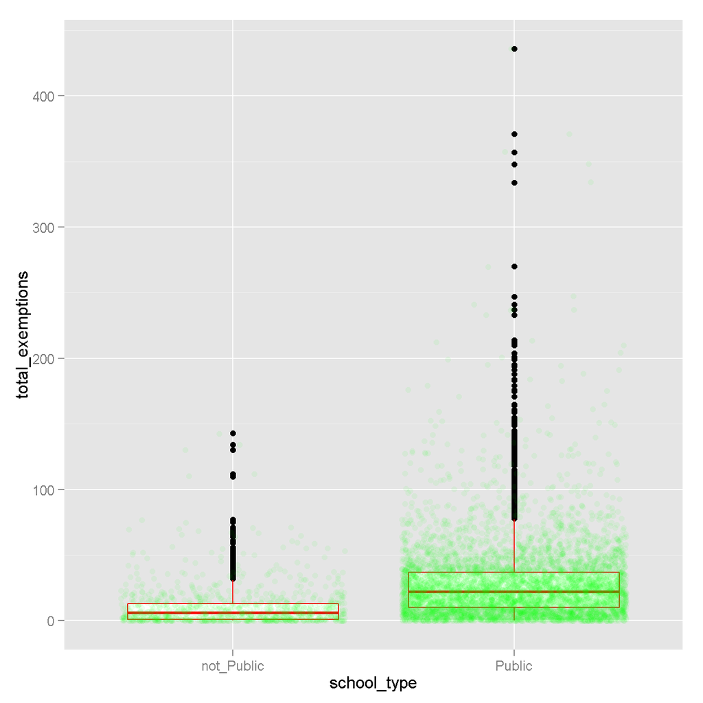

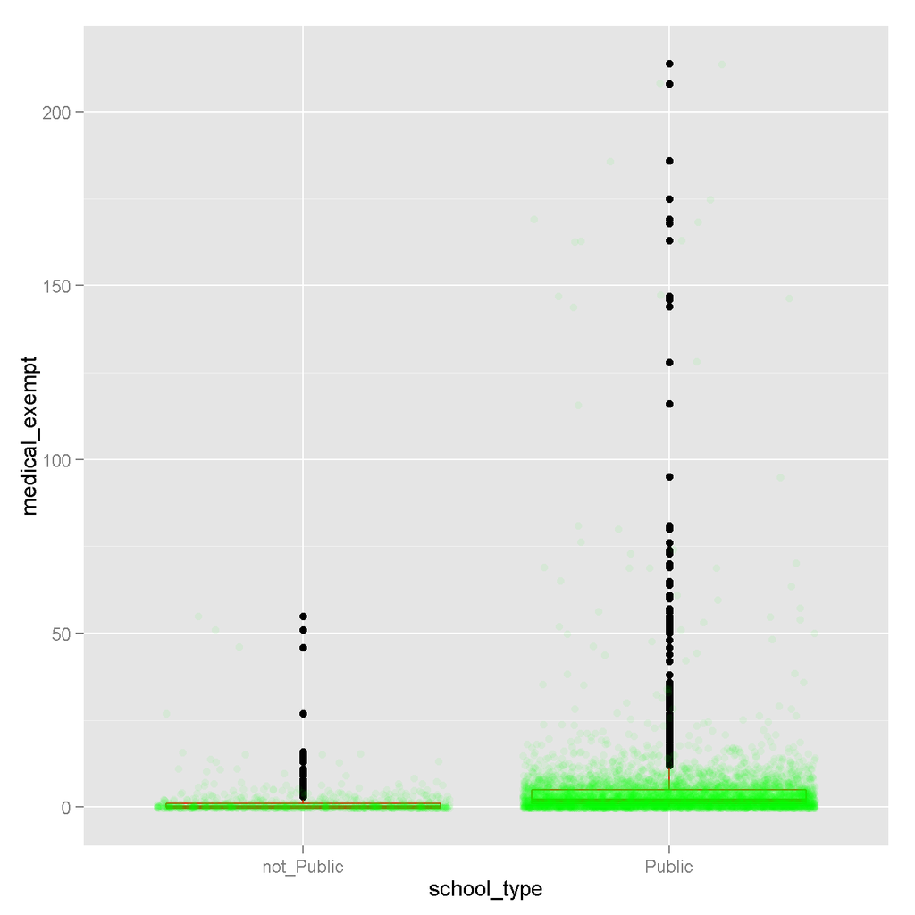

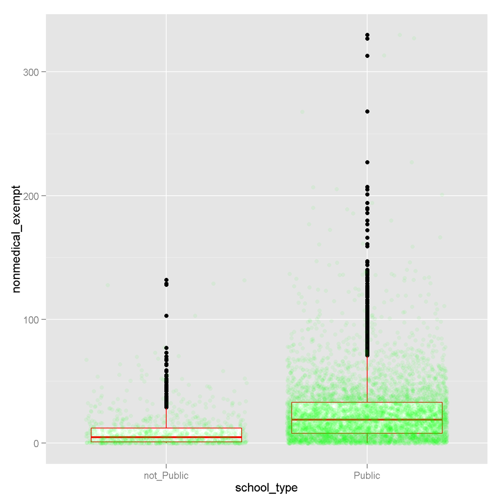

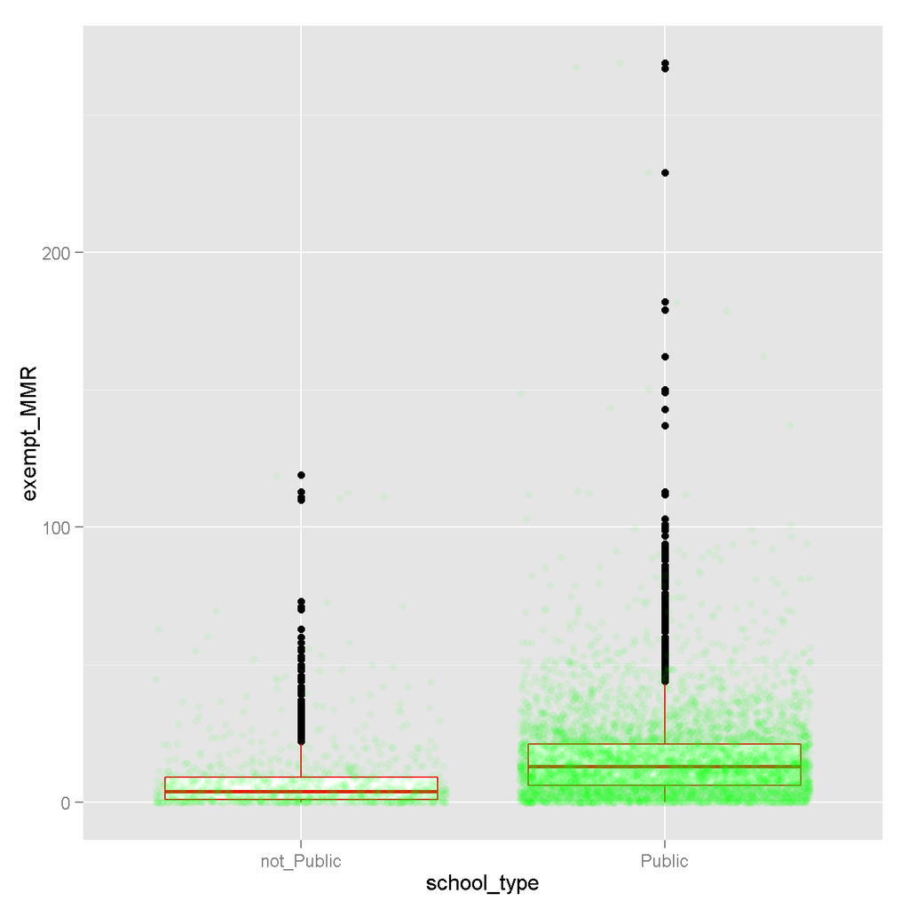

Public shcools have a higher median and larger spread of total exemptions, non-medical exemptions, and MMR exemptions. The spread is very tight for medical exemptions, with comparable medians. Some of the variability in the public schools can be explained by the fact that public schools have a larger range of enrolled students. However, this doesn’t explain observations for medical exemptions.

## Exemption rates by school type

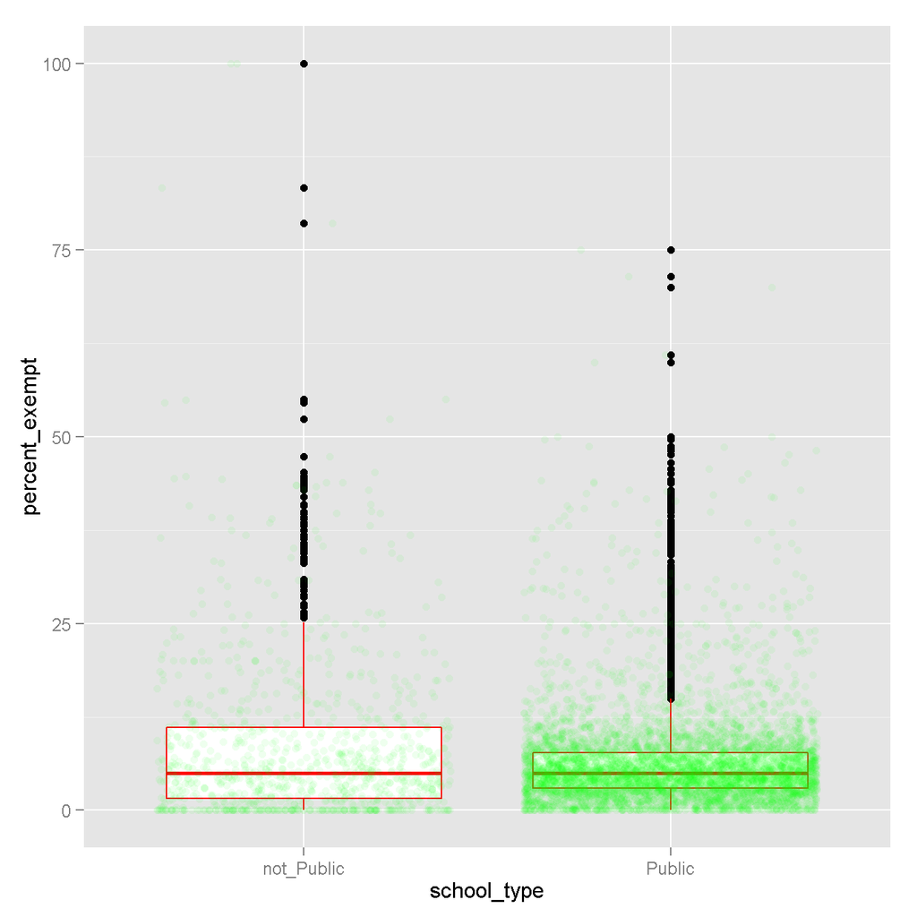

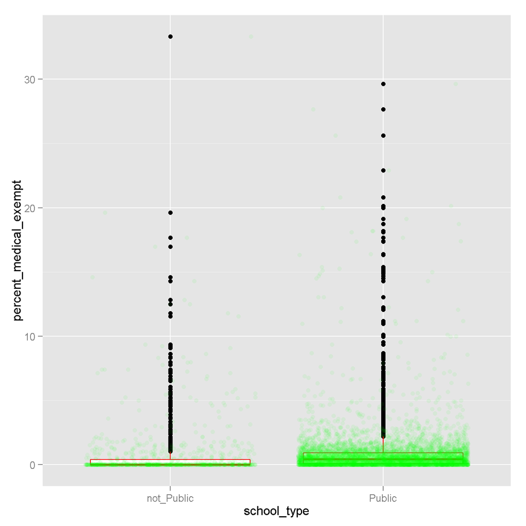

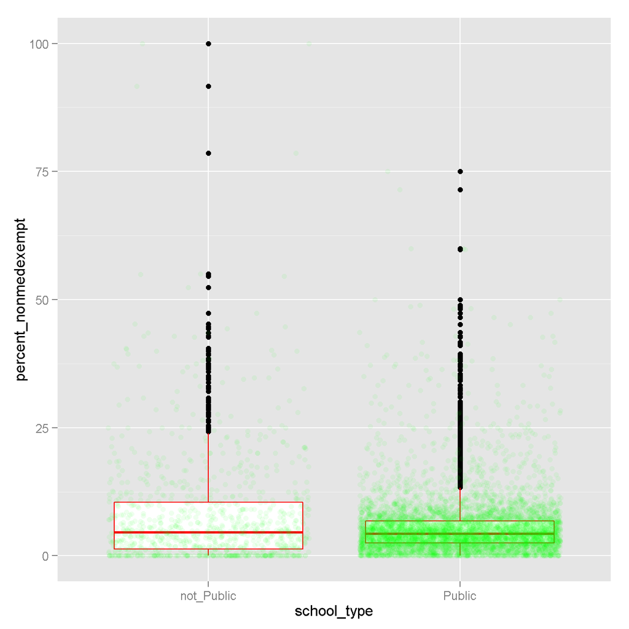

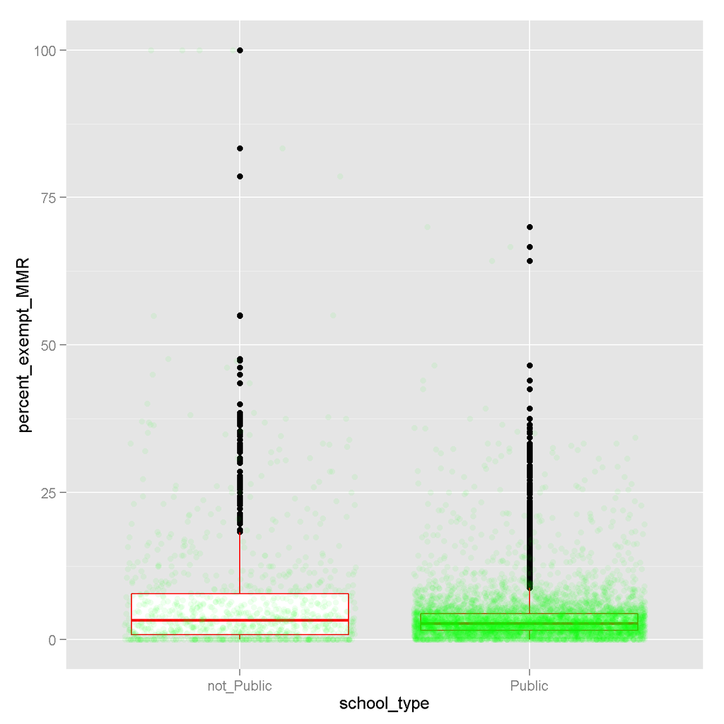

This is interesting to me. The median level is about the same for public vs. private (not-public) but the spread is much greater or private. I’ve looked at analyses from other states that essentially show that not all private schools, even by type of private school (Waldorf, Montessori) are created equal in terms of vaccination attitudes (tendency towards personal/non-medical exemptions).  
I don’t know if this is true of my data set, but there seems to be more variability in private vs. public schools. These plots suggest this is true of non-medical and MMR exemptions, but not medical exemptions.

## Specfic Exemption Rates vs. Specific Exemption Rates

How do specific exemption rates stack up against eachother, based on my analysis thus far, I would expect a correlation between non-medical exemption rates and MMR exemption rates. I would not expect a strong correlation between medical and non-medical or MMR exemption rates.

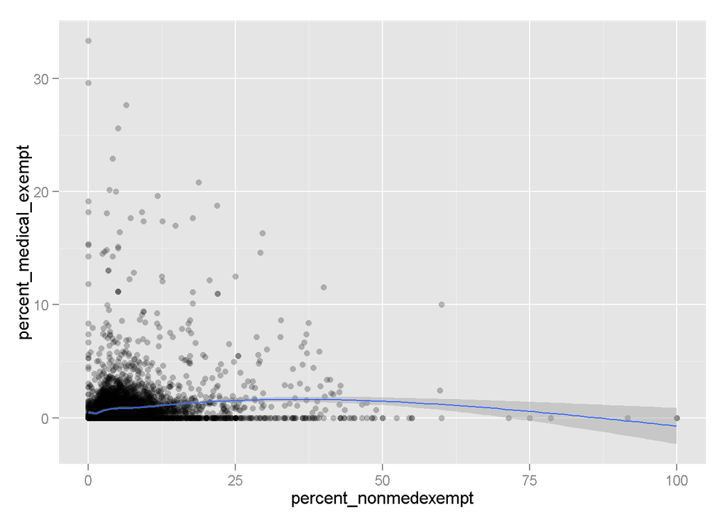

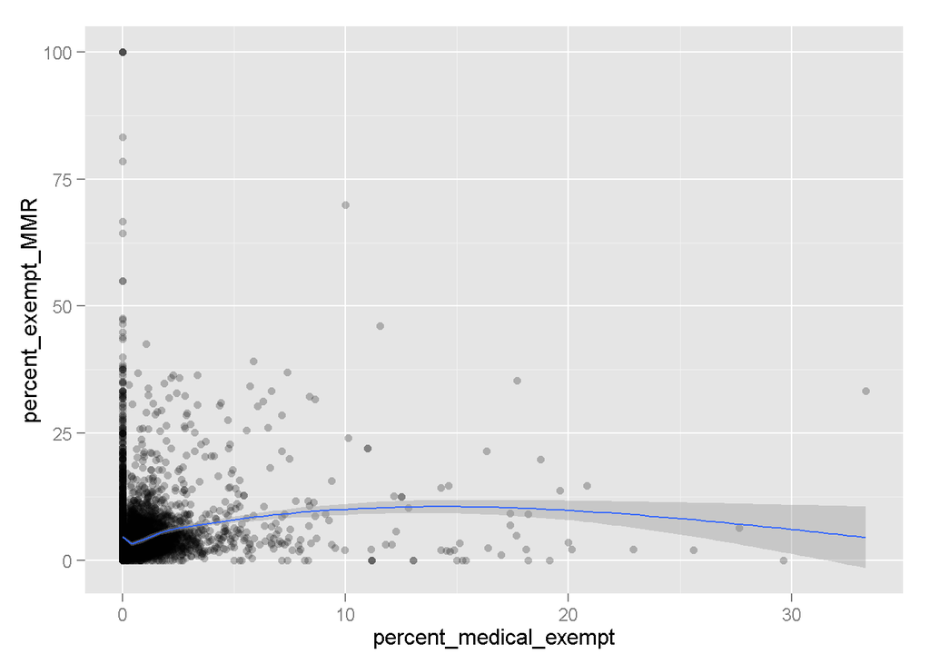

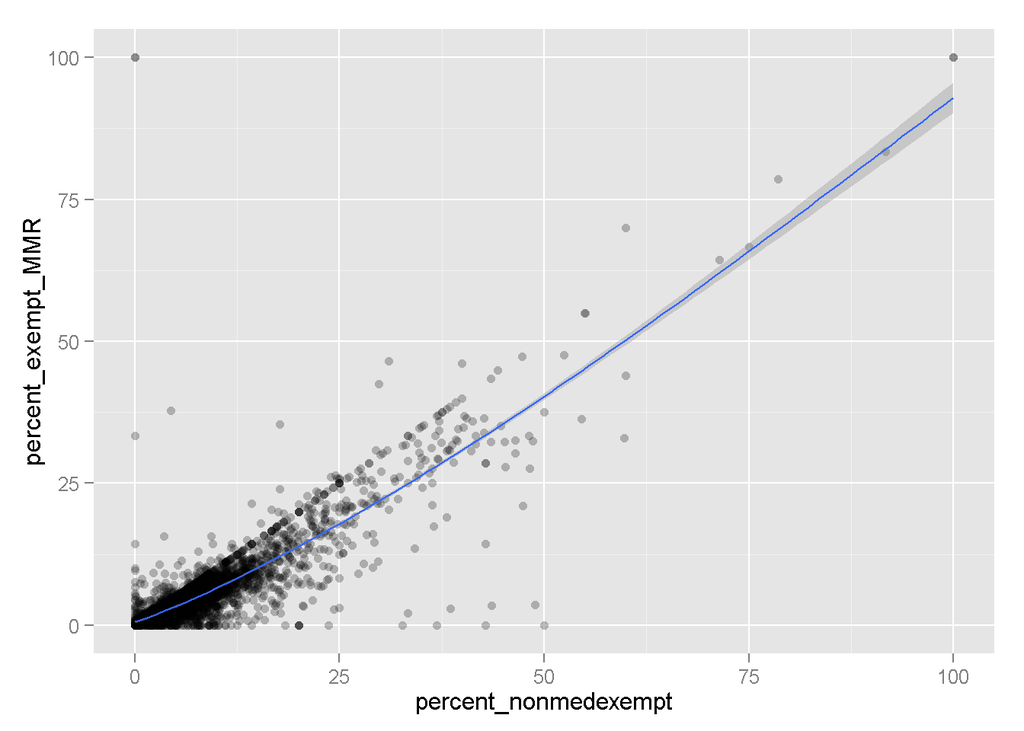

My expectations were met.Medical and non-medical exemption rates or MMR exemption rates do not have a strong relationship. Non-medical exemption rates and MMR exemption rates have strong positive relationship.

# Bivariate Analysis

### Did you observe any interesting relationships between the other features (not the main feature(s) of interest)?

The median level is about the same for public vs. private (not-public) but the spread is much greater for private. I’ve looked at analyses from other states that essentially show that not all private schools, even by type of private school (Waldorf, Montessori) are created equal in terms of vaccinations attitudes (tendency towards personal/non-medical exemptions). I don’t know if this is true of my data set, but there seems to be more variability in private vs. public schools. Plots suggest this is true of non-medical and MMR exemptions, but not medical exemptions.

Public shcools have a higher median and larger spread of total exemptions, non-medical exemptions, and MMR exemptions. The spread is very tight for medical exemptions, with comparable medians. Some of the variability in the public schools can be explained by the fact that public schools have a larger range of enrolled students. However, this doesn’t explain observations for medical exemptions.

### What was the strongest relationship you found?

- Non-medical exemption rates and total exemption rate and MMR exemption rates and non-medical exemption rates.